# Start

**Import the necesary libraries**

Import necesary libraries to start, however more libraries are going to be imported further ahead

```python
import pandas as pd
import calendar
import seaborn as sns
from matplotlib import pyplot as plt
%matplotlib inline

from math import sqrt

import tensorflow as tf
import numpy as np
import scipy.stats as stats

import dataframe_image as dfi


print('Libraries have been imported !')
```

```
Libraries have been imported !
```

## Dataset

Open the excel file and open the sheet named: '6. Precio OIC Mensual' Delete the first 5 Rows and rename the Columns

```python
# to use the URL
#file = 'https://federaciondecafeteros.org/app/uploads/2020/01/Precios-%C3%A1rea-y-producci%C3%B3n-de-caf%C3%A9.xlsx'

# to use the local file
file = pd.ExcelFile('Precios-área-y-producción-de-café.xlsx')

# name of the sheet '6. Precio OIC Mensual'
df = pd.read_excel(file, sheet_name = '6. Precio OIC Mensual')

df.head()
```

|  | Unnamed: 0 | Unnamed: 1 | Unnamed: 2 | Unnamed: 3 | Unnamed: 4 | Unnamed: 5 | Unnamed: 6 | Unnamed: 7 | Unnamed: 8 | Unnamed: 9 | Unnamed: 10 | Unnamed: 11 | Unnamed: 12 | Unnamed: 13 | Unnamed: 14 | Unnamed: 15 |
| --- | --- | --- | --- | --- | --- | --- | --- | --- | --- | --- | --- | --- | --- | --- | --- | --- |
| 0 | NaN | NaN | Precios indicativos OIC por grupos - Promedio ... | NaN | NaN | NaN | NaN | NaN | NaN | NaN | NaN | NaN | NaN | NaN | NaN | NaN |
| 1 | NaN | NaN | Centavos de dólar por libra | NaN | NaN | NaN | NaN | NaN | NaN | NaN | NaN | NaN | NaN | NaN | NaN | NaN |
| 2 | NaN | NaN | Fuente: ICO | NaN | NaN | NaN | NaN | NaN | NaN | NaN | NaN | NaN | NaN | NaN | NaN | NaN |
| 3 | NaN | NaN | NaN | NaN | NaN | NaN | NaN | NaN | NaN | NaN | NaN | NaN | NaN | NaN | NaN | NaN |
| 4 | NaN | NaN | NaN | Suaves colombianos (arábigo) | NaN | NaN | Otros suaves (arábigo) | NaN | NaN | Naturales del Brasil (arábigo) | NaN | NaN | Robustas | NaN | NaN | NaN |

```python
# removes the first column as it doesn't have any data
df = df.drop(df.columns[[0,-1]], axis = 1)

# remove the first 5 columns as is part of the format in the excel file
df = df.drop(index = df.index[0:6],
       axis = 0)

# because the first 5 rows where deleted, I need to reset the index to be 0 and not to start at row # 6
df = df.reset_index(drop=True)
```

```python
# renames the column for an easier comprenhesion
df = df.rename(columns = {'Unnamed: 1': 'Date', 'Unnamed: 2':'OIC_price',
                          'Unnamed: 3':'Colombia_ny', 'Unnamed: 4':'Colombia_europe', 'Unnamed: 5':'Colombia_average',
                          'Unnamed: 6':'Other_ny', 'Unnamed: 7':'Other_europe','Unnamed: 8':'Other_average',
                          'Unnamed: 9':'Brazil_ny', 'Unnamed: 10':'Brazil_europe', 'Unnamed: 11':'Brazil_average',
                          'Unnamed: 12':'Robustas_ny', 'Unnamed: 13':'Robustas_europe','Unnamed: 14':'Robustas_average'})
df.head()
```

|  | Date | OIC_price | Colombia_ny | Colombia_europe | Colombia_average | Other_ny | Other_europe | Other_average | Brazil_ny | Brazil_europe | Brazil_average | Robustas_ny | Robustas_europe | Robustas_average |
| --- | --- | --- | --- | --- | --- | --- | --- | --- | --- | --- | --- | --- | --- | --- |
| 0 | 2000-01-01 00:00:00 | 82.15 | 130.12 | 124.36 | 130.13 | 109.17 | 116.82 | 111.11 | 97.67 | 103.1 | 97.68 | 53.62 | 52.41 | 53.18 |
| 1 | 2000-02-01 00:00:00 | 76.15 | 124.72 | 118.67 | 124.73 | 101.17 | 110.19 | 103.44 | 91.51 | 96.58 | 91.51 | 49.41 | 47.97 | 48.85 |
| 2 | 2000-03-01 00:00:00 | 73.49 | 119.51 | 115.78 | 119.51 | 98.26 | 108.13 | 100.73 | 89.93 | 94.78 | 89.93 | 47.26 | 44.73 | 46.25 |
| 3 | 2000-04-01 00:00:00 | 69.53 | 112.67 | 109.12 | 112.67 | 92.41 | 101.51 | 94.61 | 86.46 | 90.7 | 86.46 | 45.21 | 43.31 | 44.45 |
| 4 | 2000-05-01 00:00:00 | 69.22 | 110.31 | 107.85 | 110.31 | 91.76 | 100.99 | 94.17 | 87.23 | 91.01 | 87.23 | 45.19 | 43.01 | 44.32 |

## Exploratory Data Analysis

**Description of each Column**

**Date:** Column expressing the date montly beginning January of 2000, all prices will have a reference for this date.

**OIC_price:** Is the average price of the International Coffee Organization for the month and year shown, measured in US cents/lb

**Colombia_ny:** Is the average price of Colombian Mild Arabicas for the month and year shown and is expresed in US cents/lb, in the US market

**Colombia_europe:** Is the average price of Colombian Mild Arabicas for the month and year shown and is expresed in US cents/lb, in Germany and France

**Colombia_average:** Is the weighted average Colombian Mild Arabicas Composite Indicator Price, as per "Section 4 "of the Indicator Prices SC-106/21 for the month and year shown and is expresed in US cents/lb

**Other_ny:** Is the average price of Other Mild Arabicas for the month and year shown and is expresed in US cents/lb, in the US market

**Other_europe:** Is the average price of Other Mild Arabicas for the month and year shown and is expresed in US cents/lb, in Germany and France

**Other_average:** Is the average price of Other Mild Arabicas Composite Indicator Price, as per "Section 4 "of the Indicator Prices SC-106/21 for the month and year shown and is expressed in US cents/lb

**Brazil_ny:** Is the average price of Brazilian Naturals for the month and year shown and is expresed in US cents/lb, in the US market

**Brazil_europe:** Is the average price of Brazilian Naturals for the month and year shown and is expresed in US cents/lb, in Germany and France

**Brazil_average:** Is the average price of Brazilian Naturals Composite Indicator Price, as per "Section 4 "of the Indicator Prices SC-106/21 for the month and year shown and is expressed in US cents/lb

**Robustas_ny:** Is the average price of Robustas for the month and year shown and is expresed in US cents/lb, in the US market

**Robustas_europe:** Is the average price of Robustas for the month and year shown and is expresed in US cents/lb, in Germany and France

**Robustas_average:** Is the average price of Robustas Composite Indicator Price, as per "Section 4 "of the Indicator Prices SC-106/21 for the month and year shown and is expressed in US cents/lb

**[Indicator Prices SC-106/21 ]** (https://www.ico.org/documents/cy2020-21/sc-106e-rules-indicator-prices.pdf)

Checking how many NA's are there in the dataset, what type of each column is, how many columns we have and in general all the information from the data

```python
# create a copy of the data frame to modify it and to keep the original intact
eda = df.copy()

# checking that both dataframes are diffetent in memory
print(f' Memory for df: {id(df)} ----- Memory for eda: {id(eda)}')
```

```
 Memory for df: 2168455282848 ----- Memory for eda: 2168200645840
```

```python
# exploring the data types, the amount of row and if there are NA's
eda.info()
```

```
<class 'pandas.core.frame.DataFrame'>
RangeIndex: 272 entries, 0 to 271
Data columns (total 14 columns):
 #   Column            Non-Null Count  Dtype
---  ------            --------------  -----
 0   Date              272 non-null    object
 1   OIC_price         272 non-null    object
 2   Colombia_ny       272 non-null    object
 3   Colombia_europe   272 non-null    object
 4   Colombia_average  272 non-null    object
 5   Other_ny          272 non-null    object
 6   Other_europe      272 non-null    object
 7   Other_average     272 non-null    object
 8   Brazil_ny         272 non-null    object
 9   Brazil_europe     272 non-null    object
 10  Brazil_average    272 non-null    object
 11  Robustas_ny       272 non-null    object
 12  Robustas_europe   272 non-null    object
 13  Robustas_average  272 non-null    object
dtypes: object(14)
memory usage: 29.9+ KB
```

```python
# checking if tehre are NA's
eda.isna().sum()
```

```
Date                0
OIC_price           0
Colombia_ny         0
Colombia_europe     0
Colombia_average    0
Other_ny            0
Other_europe        0
Other_average       0
Brazil_ny           0
Brazil_europe       0
Brazil_average      0
Robustas_ny         0
Robustas_europe     0
Robustas_average    0
dtype: int64
```

**Duplicates on each column**

Colombia_europe [20 - 40] On years 2001-09 and 2003-05, it was exactly the same price of the coffe

Brazil_ny[75 - 89] On years 2006-04 and 2007-06, it was exactly the same price of the coffe

Other_ny [158 - 159] On years 2013-03 and 2013-04, it was exactly the same price of the coffe

Other_europe [29 - 41] On years 2002-06 and 2003-06, it was exactly the same price of the coffe

Robustas_ny [35 - 39] On years 2002-12 and 2003-04, it was exactly the same price of the coffe

```python
# checking if there are duplicated values
dup_OIC = eda[eda.duplicated(['OIC_price'],keep = False)]
dup_Col_ny = eda[eda.duplicated(['Colombia_ny'],keep = False)]
dup_Col_europe = eda[eda.duplicated(['Colombia_europe'],keep = False)]
dup_Col_average = eda[eda.duplicated(['Colombia_average'],keep = False)]
dup_Other_ny= eda[eda.duplicated(['Other_ny'],keep = False)]
dup_Other_europe= eda[eda.duplicated(['Other_europe'],keep = False)]
dup_Other_average= eda[eda.duplicated(['Other_average'],keep = False)]
dup_Brazil_ny= eda[eda.duplicated(['Brazil_ny'],keep = False)]
dup_Brazil_europe= eda[eda.duplicated(['Brazil_europe'],keep = False)]
dup_Brazil_average= eda[eda.duplicated(['Brazil_average'],keep = False)]
dup_Robustas_ny= eda[eda.duplicated(['Robustas_ny'],keep = False)]
dup_Robustas_europe= eda[eda.duplicated(['Robustas_europe'],keep = False)]
dup_Robustas_average= eda[eda.duplicated(['Robustas_average'],keep = False)]
#print(dup_Robustas_europe)
```

The types of the columns are object, Changing them for numeric type float, so we can see the statistics

```python
# changes the format of the column 'Date' for just the year and the month
eda['Date'] = pd.to_datetime(eda['Date'], format = '%d%m%Y')

lista = list(eda.columns)
lista.pop(0)

for item in lista:
    eda[item] = eda[item].astype(float)

#checking descriptive statistics
eda.describe()

# saves the table as a png or svg
#df_styled = eda.describe().style.background_gradient()
#dfi.export(df_styled, "table statistics.png")
```

|  | OIC_price | Colombia_ny | Colombia_europe | Colombia_average | Other_ny | Other_europe | Other_average | Brazil_ny | Brazil_europe | Brazil_average | Robustas_ny | Robustas_europe | Robustas_average |
| --- | --- | --- | --- | --- | --- | --- | --- | --- | --- | --- | --- | --- | --- |
| count | 272.000000 | 272.000000 | 272.000000 | 272.000000 | 272.000000 | 272.000000 | 272.000000 | 272.000000 | 272.000000 | 272.000000 | 272.000000 | 272.000000 | 272.000000 |
| mean | 113.633237 | 153.333888 | 148.409523 | 151.222932 | 145.099616 | 143.098234 | 143.966330 | 118.365112 | 123.408718 | 121.959193 | 79.670588 | 74.456376 | 75.376692 |
| std | 43.687941 | 62.437782 | 59.732402 | 61.156478 | 58.414410 | 55.916915 | 56.927377 | 49.732689 | 51.170812 | 50.984818 | 28.448193 | 26.567300 | 26.767165 |
| min | 41.170000 | 58.920000 | 57.720000 | 58.100000 | 51.950000 | 55.760000 | 54.280000 | 37.670000 | 38.710000 | 38.630000 | 21.250000 | 22.790000 | 22.810000 |
| 25% | 88.547500 | 112.940000 | 111.697500 | 112.670000 | 108.720000 | 110.295000 | 109.712500 | 94.405000 | 96.056883 | 95.605714 | 57.895000 | 54.765000 | 55.347500 |
| 50% | 113.155682 | 144.413636 | 141.123636 | 143.529552 | 141.896818 | 138.104348 | 140.704773 | 111.980000 | 117.983409 | 116.833333 | 84.680554 | 78.150682 | 79.203636 |
| 75% | 133.130252 | 182.577237 | 178.760455 | 179.022500 | 169.232857 | 165.942045 | 166.686126 | 132.726023 | 143.199599 | 140.728880 | 103.530147 | 97.329432 | 98.367841 |
| max | 231.240000 | 319.633750 | 311.450000 | 312.950000 | 303.590000 | 297.220000 | 300.120000 | 271.390000 | 273.430000 | 273.400000 | 126.300000 | 121.300000 | 121.980000 |

The correlation between the attributes

```python
# to check the correlation
eda.corr()
```

|  | OIC_price | Colombia_ny | Colombia_europe | Colombia_average | Other_ny | Other_europe | Other_average | Brazil_ny | Brazil_europe | Brazil_average | Robustas_ny | Robustas_europe | Robustas_average |
| --- | --- | --- | --- | --- | --- | --- | --- | --- | --- | --- | --- | --- | --- |
| OIC_price | 1.000000 | 0.961247 | 0.974154 | 0.968370 | 0.983946 | 0.987328 | 0.986648 | 0.981872 | 0.988744 | 0.989057 | 0.902821 | 0.883472 | 0.888010 |
| Colombia_ny | 0.961247 | 1.000000 | 0.989911 | 0.997974 | 0.978964 | 0.978009 | 0.977207 | 0.953280 | 0.950817 | 0.952474 | 0.795684 | 0.761376 | 0.768793 |
| Colombia_europe | 0.974154 | 0.989911 | 1.000000 | 0.996692 | 0.979493 | 0.986822 | 0.982911 | 0.962704 | 0.967117 | 0.967156 | 0.810751 | 0.783200 | 0.789372 |
| Colombia_average | 0.968370 | 0.997974 | 0.996692 | 1.000000 | 0.981455 | 0.984258 | 0.981992 | 0.959397 | 0.959980 | 0.960859 | 0.802224 | 0.770656 | 0.777598 |
| Other_ny | 0.983946 | 0.978964 | 0.979493 | 0.981455 | 1.000000 | 0.995489 | 0.996963 | 0.971176 | 0.977323 | 0.977294 | 0.845858 | 0.812284 | 0.819485 |
| Other_europe | 0.987328 | 0.978009 | 0.986822 | 0.984258 | 0.995489 | 1.000000 | 0.997574 | 0.975087 | 0.984532 | 0.983430 | 0.841851 | 0.813314 | 0.819732 |
| Other_average | 0.986648 | 0.977207 | 0.982911 | 0.981992 | 0.996963 | 0.997574 | 1.000000 | 0.973195 | 0.981179 | 0.980708 | 0.846334 | 0.816121 | 0.822735 |
| Brazil_ny | 0.981872 | 0.953280 | 0.962704 | 0.959397 | 0.971176 | 0.975087 | 0.973195 | 1.000000 | 0.994153 | 0.996667 | 0.838267 | 0.819359 | 0.823952 |
| Brazil_europe | 0.988744 | 0.950817 | 0.967117 | 0.959980 | 0.977323 | 0.984532 | 0.981179 | 0.994153 | 1.000000 | 0.999492 | 0.856312 | 0.837155 | 0.841898 |
| Brazil_average | 0.989057 | 0.952474 | 0.967156 | 0.960859 | 0.977294 | 0.983430 | 0.980708 | 0.996667 | 0.999492 | 1.000000 | 0.854775 | 0.835624 | 0.840293 |
| Robustas_ny | 0.902821 | 0.795684 | 0.810751 | 0.802224 | 0.845858 | 0.841851 | 0.846334 | 0.838267 | 0.856312 | 0.854775 | 1.000000 | 0.991836 | 0.994478 |
| Robustas_europe | 0.883472 | 0.761376 | 0.783200 | 0.770656 | 0.812284 | 0.813314 | 0.816121 | 0.819359 | 0.837155 | 0.835624 | 0.991836 | 1.000000 | 0.999689 |
| Robustas_average | 0.888010 | 0.768793 | 0.789372 | 0.777598 | 0.819485 | 0.819732 | 0.822735 | 0.823952 | 0.841898 | 0.840293 | 0.994478 | 0.999689 | 1.000000 |

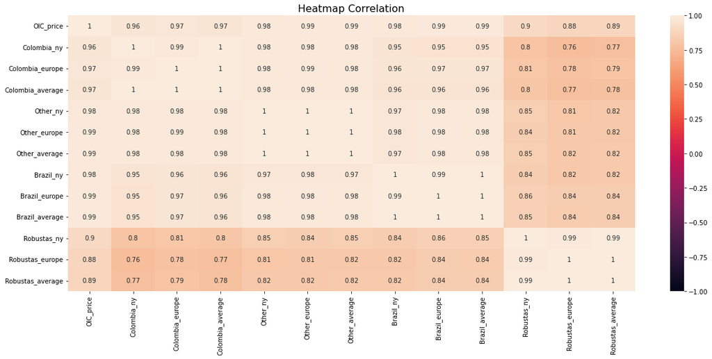

```python
# checking the correlation visually on a heat map

plt.figure(figsize = (20,8))
hm = sns.heatmap(eda.corr(), annot = True, vmin = -1, vmax = 1)
hm.set_title('Heatmap Correlation', fontdict = {'fontsize':16});
#plt.savefig('Heat Map.svg')
```

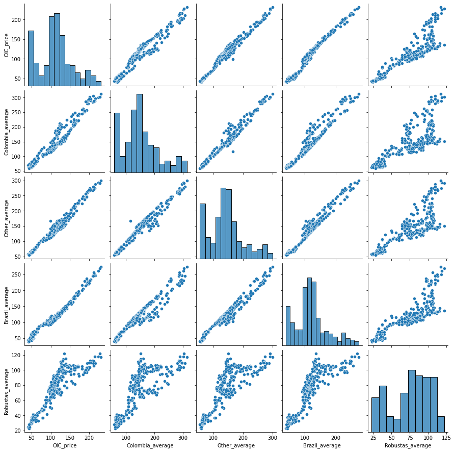

```python
# Doing a scatter plot matrix just with the average columns
sns.pairplot(eda[['OIC_price', 'Colombia_average', 'Other_average', 'Brazil_average', 'Robustas_average']]);
#plt.savefig('scatter plot.svg')
```

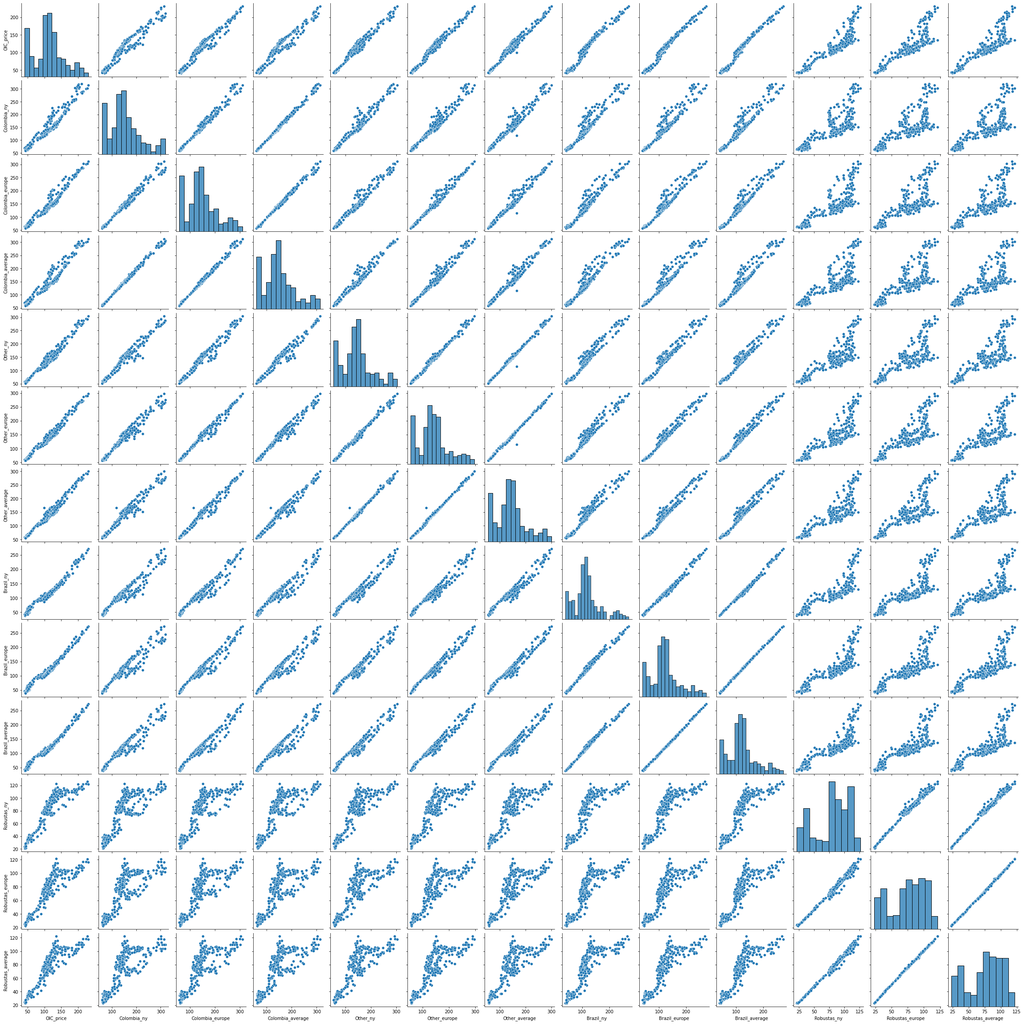

```python
# Doing a scatter plot matrix with the all columns
sns.pairplot(eda[['Date', 'OIC_price', 'Colombia_ny', 'Colombia_europe',
       'Colombia_average', 'Other_ny', 'Other_europe', 'Other_average',
       'Brazil_ny', 'Brazil_europe', 'Brazil_average', 'Robustas_ny',
       'Robustas_europe', 'Robustas_average']]);
#plt.savefig('scatter plot.jpg')
```

**Doing a box plot for each of the columns**

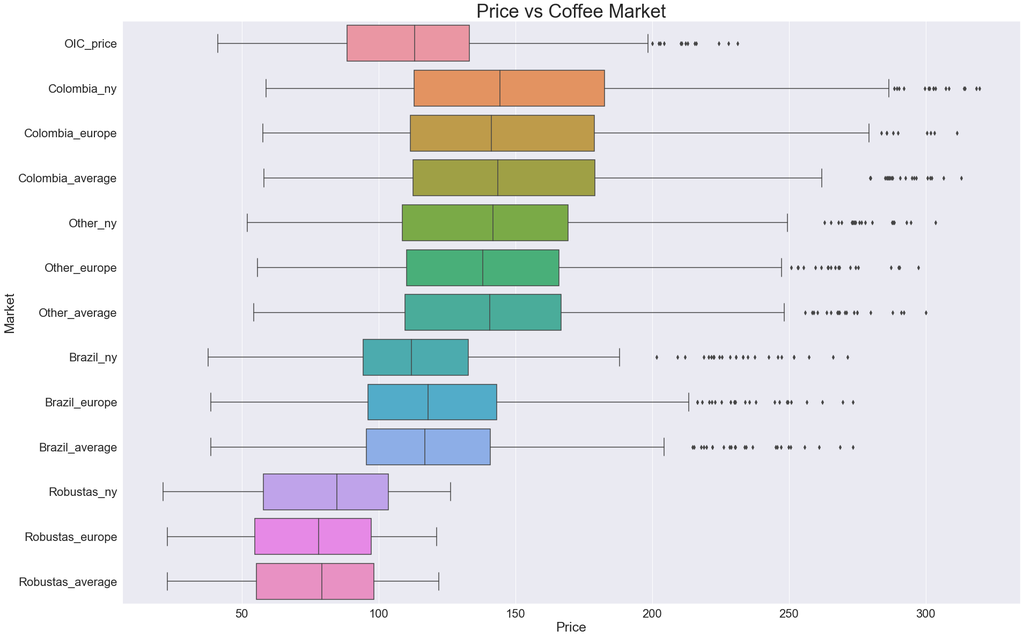

```python
# incresesthe size of the graph
plt.figure(figsize=(30,20))

# increases the size of the font
sns.set(font_scale=2)

# sets the data and the orientation
s = sns.boxplot(data = eda, orient = 'h')

# label in x and the size of it
s.set_xlabel('Price', fontsize = 25)

# label in y and the size of it
s.set_ylabel('Market', fontsize = 25)

# title and its size
s.set_title('Price vs Coffee Market', fontsize = 35)

# show the graph!
plt.show();
```

The type of coffe Robustas, has the lowest prices, while Colombian Coffee has the highest prices and the 25% of Colombian Coffee price is basically the median of the OIC Price

Graphing all columns, as a time series, to compare all of them together

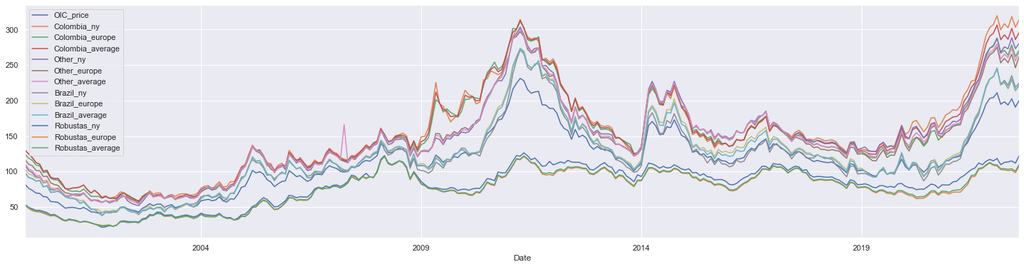

```python
# create a list with th enames of the columns
lista = list(eda.columns)
#  removes the first item of the list, which is 'Date'
lista.pop(0)

# increases the size of the font
sns.set(font_scale=1)
# selects the size of the column
plt.figure(figsize=(25,6))
# plots the axes
ax = plt.gca()

# creates a loop graphing all the columns vs 'Date'
for column in lista:
    eda.plot(x ='Date', y = column, ax = ax)

#plt.savefig('Time vs price all.svg')
```

Comparing just the averages and the OIC prices

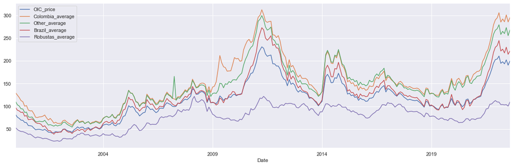

```python
lista_averages = ['OIC_price', 'Colombia_average', 'Other_average', 'Brazil_average', 'Robustas_average']
# selects the size of the column
plt.figure(figsize=(20,6))
# plots the axes
ax = plt.gca()

# creates a loop graphing all the columns vs 'Date'
for column in lista_averages:
    eda.plot(x ='Date', y = column, ax = ax)

#plt.savefig('Time vs price averages.svg')
```

```python
#'OIC_price', 'Colombia_average', 'Other_average', 'Brazil_average', 'Robustas_average'
eda_subset = eda.drop(['Date'], axis = 1)
```

```python
# counts the number of outliers per column
def IQR(df):
    q1 = df.quantile(0.25)
    q3 = df.quantile(0.75)
    IQR = q3 - q1
    x = df[((df<(q1-1.5*IQR)) | (df>(q3+1.5*IQR)))]
    print(f'Number of outliers {str(len(x))}')
    print(f'max outlier {x.max()}, min outlier {x.min()}')

for i in eda_subset:
    print('\n',i)
    print(IQR(eda_subset[i]))
```

```
 OIC_price
Number of outliers 13
max outlier 231.24, min outlier 200.11
None

 Colombia_ny
Number of outliers 16
max outlier 319.63375, min outlier 288.43
None

 Colombia_europe
Number of outliers 9
max outlier 311.45, min outlier 283.74
None

 Colombia_average
Number of outliers 19
max outlier 312.95, min outlier 279.55681818181813
None

 Other_ny
Number of outliers 19
max outlier 303.59, min outlier 262.94
None

 Other_europe
Number of outliers 19
max outlier 297.22, min outlier 250.75
None

 Other_average
Number of outliers 19
max outlier 300.12, min outlier 255.90657034106954
None

 Brazil_ny
Number of outliers 25
max outlier 271.39, min outlier 201.60674603174598
None

```

[output cut: 9 more lines]

```

 Robustas_ny
Number of outliers 0
max outlier nan, min outlier nan
None

 Robustas_europe
Number of outliers 0
max outlier nan, min outlier nan
None

 Robustas_average
Number of outliers 0
max outlier nan, min outlier nan
None
```

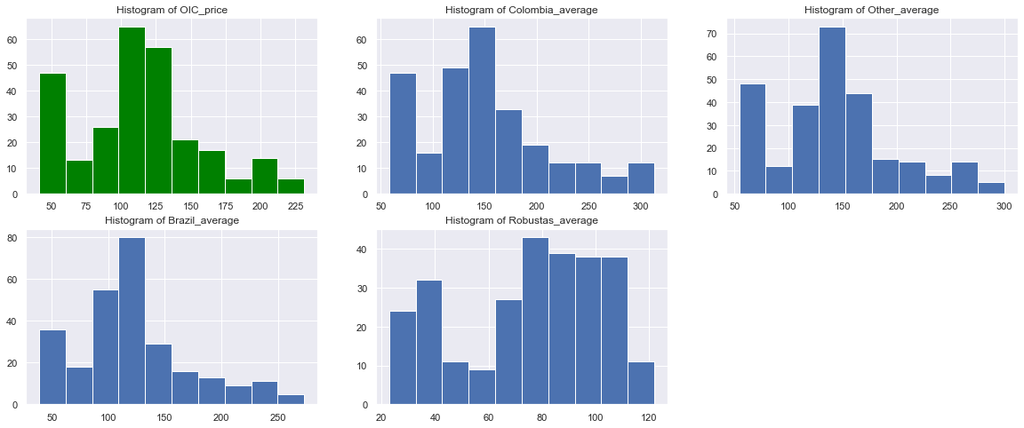

```python
# plotting just the average columns and the OIC_price
plt.figure(figsize=(20,8))
plt.subplot(2,3,1)
plt.hist(eda['OIC_price'], color = 'green')
plt.title('Histogram of OIC_price')

plt.subplot(2,3,2)
plt.hist(eda['Colombia_average'])
plt.title('Histogram of Colombia_average')

plt.subplot(2,3,3)
plt.hist(eda['Other_average'])
plt.title('Histogram of Other_average')

plt.subplot(2,3,4)
plt.hist(eda['Brazil_average'])
plt.title('Histogram of Brazil_average')

plt.subplot(2,3,5)
plt.hist(eda['Robustas_average'])
plt.title('Histogram of Robustas_average');

#plt.savefig('hist averages.svg')
```

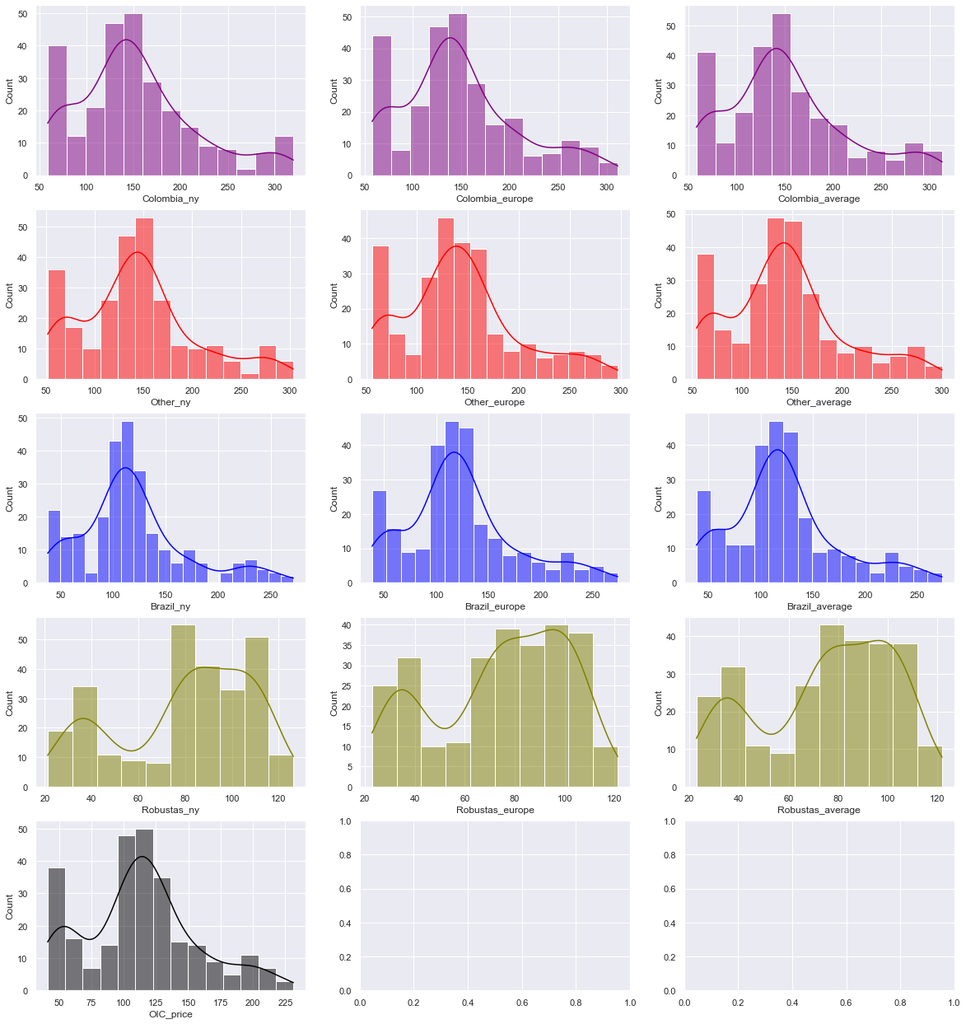

```python
fig, axes = plt.subplots(5,3, figsize = (20,22))
sns.histplot(eda_subset['Colombia_ny'], kde = True, ax = axes[0,0], color = 'purple')
sns.histplot(eda_subset['Colombia_europe'], kde = True, ax = axes[0,1], color = 'purple')
sns.histplot(eda_subset['Colombia_average'], kde = True, ax = axes[0,2], color = 'purple')

sns.histplot(eda_subset['Other_ny'], kde = True, ax = axes[1,0], color = 'red')
sns.histplot(eda_subset['Other_europe'], kde = True, ax = axes[1,1], color = 'red')
sns.histplot(eda_subset['Other_average'], kde = True, ax = axes[1,2], color = 'red')

sns.histplot(eda_subset['Brazil_ny'], kde = True, ax = axes[2,0], color = 'blue')
sns.histplot(eda_subset['Brazil_europe'], kde = True, ax = axes[2,1], color = 'blue')
sns.histplot(eda_subset['Brazil_average'], kde = True, ax = axes[2,2], color = 'blue')

sns.histplot(eda_subset['Robustas_ny'], kde = True, ax = axes[3,0], color = 'olive')
sns.histplot(eda_subset['Robustas_europe'], kde = True, ax = axes[3,1], color = 'olive')
sns.histplot(eda_subset['Robustas_average'], kde = True, ax = axes[3,2], color = 'olive')

sns.histplot(eda_subset['OIC_price'], kde = True, ax = axes[4, 0], color = 'black')
plt.show()
```

```python
# grouping by the year and checking the average price every year
eda.groupby(eda['Date'].dt.year).mean()
#df_styled = eda.groupby(eda['Date'].dt.year).mean().style.background_gradient()
#dfi.export(df_styled, "avg per year.svg")
```

| Date | OIC_price | Colombia_ny | Colombia_europe | Colombia_average | Other_ny | Other_europe | Other_average | Brazil_ny | Brazil_europe | Brazil_average | Robustas_ny | Robustas_europe | Robustas_average |
| --- | --- | --- | --- | --- | --- | --- | --- | --- | --- | --- | --- | --- | --- |
| 2000 | 64.245000 | 102.600833 | 99.801667 | 102.603333 | 85.094167 | 92.889167 | 87.075000 | 79.861667 | 83.666667 | 79.862500 | 42.118333 | 40.358333 | 41.413333 |
| 2001 | 45.591667 | 72.205000 | 68.235833 | 72.050833 | 61.937500 | 63.139167 | 62.283333 | 50.523333 | 52.415000 | 50.699167 | 27.300833 | 27.485833 | 27.540833 |
| 2002 | 47.755000 | 65.265000 | 64.780833 | 64.901667 | 60.439167 | 62.345833 | 61.554167 | 45.103333 | 45.920000 | 45.234167 | 30.835000 | 29.776667 | 30.027500 |
| 2003 | 51.896667 | 67.305000 | 64.336667 | 65.329167 | 64.088333 | 64.301667 | 64.199167 | 50.820000 | 50.158333 | 50.314167 | 38.391667 | 36.495833 | 36.944167 |
| 2004 | 62.150833 | 83.850833 | 79.492500 | 81.438333 | 80.145000 | 80.643333 | 80.466667 | 68.175833 | 69.110000 | 68.968333 | 37.279167 | 35.657500 | 35.978333 |
| 2005 | 89.344167 | 117.000000 | 114.670833 | 115.730833 | 114.292500 | 114.826667 | 114.830833 | 101.329167 | 102.485000 | 102.290000 | 53.375833 | 49.859167 | 50.505000 |
| 2006 | 95.745000 | 117.915000 | 115.704167 | 116.804167 | 113.950833 | 114.795833 | 114.400833 | 102.878333 | 104.186667 | 103.920833 | 70.282500 | 66.982500 | 67.558333 |
| 2007 | 107.679167 | 126.740833 | 124.703333 | 125.570000 | 123.163333 | 123.808333 | 127.832500 | 110.689167 | 112.064167 | 111.791667 | 88.263333 | 86.295000 | 86.371667 |
| 2008 | 125.465787 | 146.076027 | 144.266040 | 145.371284 | 139.630237 | 141.985913 | 141.213821 | 124.471924 | 129.475855 | 128.350946 | 107.656345 | 106.318875 | 106.561649 |
| 2009 | 115.670166 | 180.873853 | 174.579426 | 177.432834 | 141.651272 | 145.480386 | 143.841181 | 111.393568 | 116.553699 | 115.325063 | 77.159199 | 74.020763 | 74.578187 |
| 2010 | 148.160000 | 224.622500 | 227.076667 | 226.333333 | 195.440833 | 197.624167 | 196.968333 | 146.682500 | 156.916667 | 154.663333 | 85.074167 | 78.455833 | 79.552500 |
| 2011 | 210.389167 | 283.817500 | 283.668333 | 283.836667 | 273.201667 | 269.545000 | 271.073333 | 243.667500 | 248.723333 | 247.615000 | 115.992500 | 107.911667 | 109.206667 |
| 2012 | 156.358660 | 203.947778 | 200.525814 | 202.145996 | 187.591598 | 185.759147 | 186.534793 | 171.367051 | 176.131668 | 175.028858 | 110.578368 | 101.296184 | 102.763990 |
| 2013 | 119.511515 | 148.253571 | 147.531932 | 147.868106 | 141.080238 | 138.417803 | 139.525152 | 117.948095 | 123.557917 | 122.233409 | 100.495635 | 92.953447 | 94.160833 |
| 2014 | 155.259167 | 198.090833 | 198.164167 | 197.949167 | 202.849167 | 199.078333 | 200.391667 | 161.298333 | 175.288333 | 171.592500 | 105.600833 | 99.469167 | 100.433333 |
| 2015 | 124.672245 | 149.875938 | 154.017292 | 151.797906 | 160.532485 | 159.540010 | 159.939615 | 123.107688 | 135.718145 | 132.450318 | 94.199219 | 86.844965 | 88.048500 |
| 2016 | 127.381287 | 155.582169 | 155.369568 | 155.378077 | 164.632859 | 163.487515 | 163.876739 | 124.183534 | 142.724285 | 137.864849 | 94.276935 | 87.470577 | 88.629187 |
| 2017 | 126.678882 | 154.069886 | 150.412525 | 152.374415 | 152.410369 | 149.504372 | 150.726456 | 126.551287 | 133.781123 | 131.907557 | 104.091137 | 100.278229 | 100.950453 |
| 2018 | 109.035612 | 139.591534 | 133.260508 | 136.698098 | 137.401621 | 129.104963 | 132.727196 | 109.619033 | 115.099169 | 113.648542 | 88.343472 | 84.029311 | 84.795899 |
| 2019 | 100.517620 | 137.065562 | 129.187535 | 133.599465 | 137.459949 | 125.524315 | 130.657423 | 100.073484 | 101.988932 | 101.527120 | 80.055400 | 72.153073 | 73.562791 |
| 2020 | 107.937806 | 166.277684 | 146.097829 | 157.665431 | 156.809259 | 146.766945 | 150.723610 | 102.455498 | 107.856665 | 106.423287 | 78.201469 | 66.676662 | 68.753262 |
| 2021 | 151.288532 | 228.421976 | 206.527908 | 219.045860 | 209.884778 | 201.421142 | 204.624669 | 158.225545 | 163.010229 | 161.701507 | 99.806236 | 87.735133 | 89.874791 |
| 2022 | 199.429155 | 309.178232 | 272.306706 | 293.692236 | 277.856212 | 260.354944 | 266.655479 | 228.774979 | 225.648634 | 226.492861 | 114.733619 | 103.729691 | 105.490708 |

```python
# 2011 has been the higest price for coffee for 'OIC_price', even 10 years after today!
avg_year = eda.groupby(eda['Date'].dt.year)['OIC_price'].mean()
avg_year.agg(['min','max'])
```

```
min     45.591667
max    210.389167
Name: OIC_price, dtype: float64
```

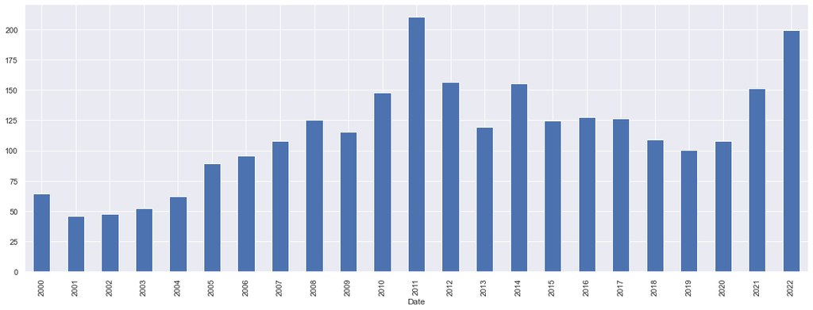

```python
# ploting the Average per year
avg_year.plot( kind = 'bar', figsize = (20,7));
#plt.savefig('avg_year.svg')
```

```python
# Months of February and March are when the coffe has the highest prices, not a significant increase in price with only 3%
avg_month = eda.groupby(eda['Date'].dt.month_name())['OIC_price'].mean()
avg_month.agg(['min','max'])
```

```
min    111.489454
max    115.209163
Name: OIC_price, dtype: float64
```

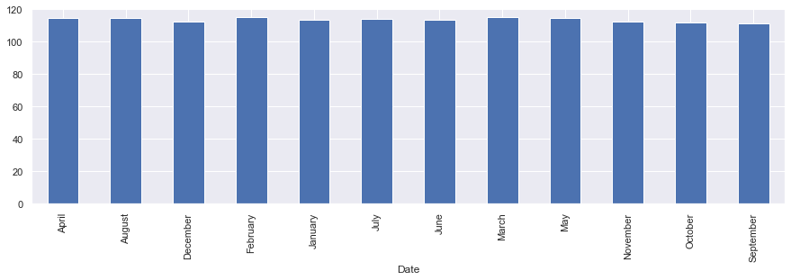

```python
# ploting the average each month
avg_month.plot( kind = 'bar', figsize = (15,4));
```

# Start of Machine Learning Regression Algorithms

```python
# creates a copy of the original dataframe
test = df.copy()

# saves the column 'Date' as date  and removes the column 'Date' from the new dataframe 'test'
date = test['Date']
test = test.drop(['Date'], axis = 1)

test = test.astype(float) # converts everything to float
```

```python
import statsmodels.regression.linear_model as sm
import statsmodels.api as am

X = test.iloc[:, 1:] # All the variables but OIC_price
y = test.iloc[:, 0] # OIC_price
```